# Predykcja zachorowań na nowotwory piersi w Polsce

Dominik Ambroziak, Michał Jaworski, Iwona Majewska, Krzysztof Smutek

14 czerwca 2016

# 1 Wstęp

Cel, który postawiliśmy sobie w trzeciej fazie projektu to predykcja liczby chorych na nowotwory piersi (C50_D05 według klasyfikacji ICD-10) w roku 2013 w podziale na płeć, grupę wiekową oraz powiaty.

Dostępne dane zawierały informacje o liczbie chorych w zależności od stadium choroby, powiatu, płci i grupy wiekowej dla lat 2010 - 2012 oraz liczbę nowych przypadków. Rozważane grupy wiekowe to:

- 0 - 44 lata
- 45 - 54 lata
- 55 - 64 lata
- 65 - 74 lata
- 75 - 84 lata
- 85+ lat.

Dane dotyczące liczby chorych w powiatach znormalizowano przez całkowitą liczbę mieszkańców danego powiatu.

Model został stworzony i przetestowany na podstawie danych z lat 2010 - 2012, gdzie dane z roku 2010 i 2011 modelowały zachorowania w roku 2012. Następnie dane z lat 2011 i 2012 zostały użyte do predykcji zachorowań w roku 2013.

Zbudowany model uwzględniał:

- zmienną jakościową płeć
- zmienną jakościową grupa wiekowa
- znormalizowaną liczbę chorych w poszczególnych stadiach choroby oraz liczbę nowych przypadków zachorowań
- stopień urbanizacji powiatów
- stopę bezrobocia w powiatach
- średnie wynagrodzenie w województwach
- procent populacji wojewódzwta mający nadwagę (niezmienny w kolejnych latach)

Stopień urbanizacji powiatów wprowadzono do modelu zamiast obecnej w fazie drugiej projektu zmiennej binarnej rozróżniającej powiaty grodzkie i ziemskie. Stopę bezrobocia i wynagrodzenie wprowadzono do modelu, aby oddać poziom życia w regionach. Poniższa tabela pokazuje przykładową macierz zmiennych w modelu.

```
##   gender     age  Stage1_1  Stage2_1  Stage3_1 Stage4_1     new_1
## 1      K  <0-44> 0.6734007 1.3468013 1.3468013 0.000000  3.367003
## 2      K <45-54> 3.5914703 4.4893378 3.1425365 3.367003 14.590348
## 3      K <55-64> 4.7138047 8.3052750 6.0606061 0.000000 19.079686
## 4      K <65-74> 1.2345679 2.9180696 1.4590348 1.122334  6.734007
## 5      K <75-84> 1.5151515 0.4489338 0.2805836 0.000000  2.244669
## 6      K     85+ 0.0000000 0.0000000 1.1223345 0.000000  1.122334
##   stopa.bezrob_1 urbaniz_1 wynagr.woj_1 nadwaga.woj_1  Stage1_2 Stage2_2
## 1           15.7 0.4922222         3436         51.93 0.5523153 0.938936
## 2           15.7 0.4922222         3436         51.93 4.7499116 4.639449
## 3           15.7 0.4922222         3436         51.93 6.4620891 9.665518
## 4           15.7 0.4922222         3436         51.93 1.9883351 4.970838
## 5           15.7 0.4922222         3436         51.93 1.6569459 1.601714
## 6           15.7 0.4922222         3436         51.93 0.0000000 0.000000
##    Stage3_2 Stage4_2     new_2 stopa.bezrob_2 urbaniz_2 wynagr.woj_2
## 1 0.7180099 1.104631  3.313892       13.82222 0.4908235         3584
## 2 4.9708378 0.000000 14.360198       13.82222 0.4908235         3584
## 3 7.0696359 3.313892 26.511135       13.82222 0.4908235         3584
## 4 2.9825027 1.104631 11.046306       13.82222 0.4908235         3584
## 5 1.1598621 1.104631  5.523153       13.82222 0.4908235         3584
## 6 0.0000000 0.000000  0.000000       13.82222 0.4908235         3584
```

Aby wybrać model najlepiej stosujący się do naszych danych, przetestowane zostały różne podejścia, zarówno liniowe jak i nieliniowe.

Modele liniowe:

- pełny model liniowy
- model liniowy z wyborem parametrów przy pomocy kryterium AIC
- model liniowy z wyborem parametrów przy pomocy kryterium BIC
- model ridge regression (α = 0), lasso (α = 1), half (α = 1/2)
- principal component regression wełnowymiarowe i z trzema komponentami.

Modele nieliniowe:

- algorytm k-najbliższych sąsiadów
- drzewa decyzyjne
- lasy losowe
- gradient boosting

Modele były testowane na podstawie dystrybucji błędu średniokwadratowego (MSE). Aby go obliczyć, zbiór danych dzielono na część treningową i testową w proporcji 3:1. Wytrenowany model stosowano do predykcji na zbiorze testowym. Procedurę powtarzano 100 razy.

Najlepszym modelem pod kątem minimalizacji błędu średniokwadratowego okazały się lasy losowe.

# 2 Modele liniowe

## 2.1 Pełny model liniowy

Na początku postanowiliśmy wypróbować zwykły (pełny) model liniowy

```
##
## Call:
## lm(formula = dane$chore ~ ., data = dane, model = TRUE)
##
## Residuals:
##      Min       1Q   Median       3Q      Max
## -15.5795  -1.2388  -0.0985   0.8837  20.8442
##
## Coefficients:
##                   Estimate Std. Error t value Pr(>|t|)
## (Intercept)       0.772083   0.684682   1.128  0.25953
## Stage1           -0.341087   0.266942  -1.278  0.20140
## Stage2           -0.384690   0.261462  -1.471  0.14128
## Stage3           -0.380295   0.261454  -1.455  0.14587
## Stage4           -0.384441   0.260216  -1.477  0.13964
## new               0.680968   0.259454   2.625  0.00870 **
## stopa.bezrob     -0.061706   0.036281  -1.701  0.08906 .
## urbaniz           4.960989   8.633912   0.575  0.56559
## wynagr.woj       -0.001718   0.001306  -1.315  0.18868
## nadwaga.woj       0.001513   0.011323   0.134  0.89372
## Stage1.1          0.330492   0.277725   1.190  0.23411
## Stage2.1          0.244761   0.270080   0.906  0.36485
## Stage3.1          0.210362   0.271319   0.775  0.43819
## Stage4.1          0.219320   0.270431   0.811  0.41741
## new.1             0.116088   0.268695   0.432  0.66573
## stopa.bezrob.1    0.066828   0.036027   1.855  0.06367 .
## urbaniz.1        -4.257261   8.657380  -0.492  0.62292
## wynagr.woj.1      0.001850   0.001230   1.504  0.13271
## `rak$age<45-54>`  0.837126   0.146892   5.699 1.28e-08 ***
## `rak$age<55-64>`  1.821282   0.158501  11.491  < 2e-16 ***
## `rak$age<65-74>`  0.882686   0.145704   6.058 1.49e-09 ***
## `rak$age<75-84>`  0.224648   0.144430   1.555  0.11992
## `rak$age85+`     -0.557239   0.144747  -3.850  0.00012 ***
## gender           -2.530806   0.128174 -19.745  < 2e-16 ***
## ---
## Signif. codes:  0 '***' 0.001 '**' 0.01 '*' 0.05 '.' 0.1 ' ' 1
##
## Residual standard error: 2.755 on 4524 degrees of freedom
## Multiple R-squared:  0.7556, Adjusted R-squared:  0.7543
## F-statistic:   608 on 23 and 4524 DF,  p-value: < 2.2e-16
```

Istotnymi zmiennymi okazały się te jakościowe wprowadzające podział na płeń i grupy wiekowe, jak róWnież liczba nowych przypadków.

Aby ograniczyć liczbę parametrów, użyto kryteriów AIC oraz BIC.

## 2.2 Optymalny model według kryterium AIC

```
##
## Call:
## lm(formula = dane$chore ~ new + stopa.bezrob + urbaniz + Stage1.1 +
##     Stage2.1 + Stage3.1 + Stage4.1 + stopa.bezrob.1 + wynagr.woj.1 +
##     `rak$age<45-54>` + `rak$age<55-64>` + `rak$age<65-74>` +
##     `rak$age<75-84>` + `rak$age85+` + gender, data = dane, model = TRUE)
##
## Residuals:
##      Min       1Q   Median       3Q      Max
## -15.6349  -1.2430  -0.0973   0.8856  20.8522
##
## Coefficients:
##                    Estimate Std. Error t value Pr(>|t|)
## (Intercept)       0.7807530  0.4168622   1.873   0.0611 .
## new               0.3043067  0.0137742  22.093  < 2e-16 ***
## stopa.bezrob     -0.0601312  0.0358122  -1.679   0.0932 .
## urbaniz           0.7019908  0.1582749   4.435 9.41e-06 ***
## Stage1.1          0.4486474  0.0568077   7.898 3.54e-15 ***
## Stage2.1          0.3600455  0.0231104  15.579  < 2e-16 ***
## Stage3.1          0.3276753  0.0317803  10.311  < 2e-16 ***
## Stage4.1          0.3363313  0.0440361   7.638 2.68e-14 ***
## stopa.bezrob.1    0.0641709  0.0354228   1.812   0.0701 .
## wynagr.woj.1      0.0002463  0.0001019   2.417   0.0157 *
## `rak$age<45-54>`  0.8274153  0.1466666   5.641 1.79e-08 ***
## `rak$age<55-64>`  1.8050865  0.1577717  11.441  < 2e-16 ***
## `rak$age<65-74>`  0.8647120  0.1445304   5.983 2.36e-09 ***
## `rak$age<75-84>`  0.2063352  0.1427887   1.445   0.1485
## `rak$age85+`     -0.5744971  0.1440999  -3.987 6.80e-05 ***
## gender           -2.5067976  0.1269988 -19.739  < 2e-16 ***
## ---
## Signif. codes:  0 '***' 0.001 '**' 0.01 '*' 0.05 '.' 0.1 ' ' 1
##
## Residual standard error: 2.754 on 4532 degrees of freedom
## Multiple R-squared:  0.7553, Adjusted R-squared:  0.7545
## F-statistic: 932.7 on 15 and 4532 DF,  p-value: < 2.2e-16
```

W modelu istotna jest, poza jakościowymi kryteriami płci i wieku oraz informacjami o liczbie chorych w poszczególnych stadiach, urbanizacja powiatu. Inne mierniki jakości życia okazują się nie mieć tak dużego znaczenia.

## 2.3 Optymalny model według kryterium BIC

```
##
## Call:
## lm(formula = dane$chore ~ new + urbaniz + Stage1.1 + Stage2.1 +
##     Stage3.1 + Stage4.1 + `rak$age<45-54>` + `rak$age<55-64>` +
##     `rak$age<65-74>` + `rak$age85+` + gender, data = dane, model = TRUE)
##
## Residuals:
##      Min       1Q   Median       3Q      Max
## -15.9319  -1.2514  -0.0807   0.9222  21.1485
##
## Coefficients:
##                  Estimate Std. Error t value Pr(>|t|)
## (Intercept)       1.84540    0.13056  14.134  < 2e-16 ***
## new               0.30476    0.01378  22.113  < 2e-16 ***
## urbaniz           0.64260    0.15251   4.213 2.56e-05 ***
## Stage1.1          0.45591    0.05669   8.043 1.11e-15 ***
## Stage2.1          0.35700    0.02308  15.467  < 2e-16 ***
## Stage3.1          0.32800    0.03175  10.330  < 2e-16 ***
## Stage4.1          0.33996    0.04368   7.783 8.68e-15 ***
## `rak$age<45-54>`  0.72410    0.12815   5.651 1.70e-08 ***
## `rak$age<55-64>`  1.70078    0.13987  12.159  < 2e-16 ***
## `rak$age<65-74>`  0.76143    0.12517   6.083 1.28e-09 ***
## `rak$age85+`     -0.67673    0.12566  -5.386 7.59e-08 ***
## gender           -2.50356    0.12706 -19.703  < 2e-16 ***
## ---
## Signif. codes:  0 '***' 0.001 '**' 0.01 '*' 0.05 '.' 0.1 ' ' 1
##
## Residual standard error: 2.757 on 4536 degrees of freedom
## Multiple R-squared:  0.7546, Adjusted R-squared:  0.754
## F-statistic:  1268 on 11 and 4536 DF,  p-value: < 2.2e-16
```

Model BIC jeszcze bardziej ograniczył liczbę parametrów w potównaniu do AIC. Z dodatkowych parametrów wzięta pod uwagę została tylko urbanizacja.

Wypróbowano też metody regresji z regularyzacją (lasso, ridge i half dla parametru α = 1/2) oraz PCR pełny i trzykomponentowy. Jednak ich jakość oceniana przez wartość MSE jest gorsza, dlatego nie są omawiane bardziej szczegółowo.

# 3 Porównanie metod liniowych

Poniższa tabela prezentuje średni błąd kwadratowy dla różnych metod liniowych.

```
##                   sort(MSE)
## BIC                7.496216
## AIC                7.705099
## lm                 7.734624
## LASSO              9.901947
## PCR               10.139235
## cv.glment_alpha=2 10.256062
## RIGID             17.444075
## PCR_3_komponenty  23.931862
```

Jako, że metody RIGID i trzykomponentowy PCR wykazują zdecydowanie większe MSE, są pominięte na wykresach dystrybucji błędów.

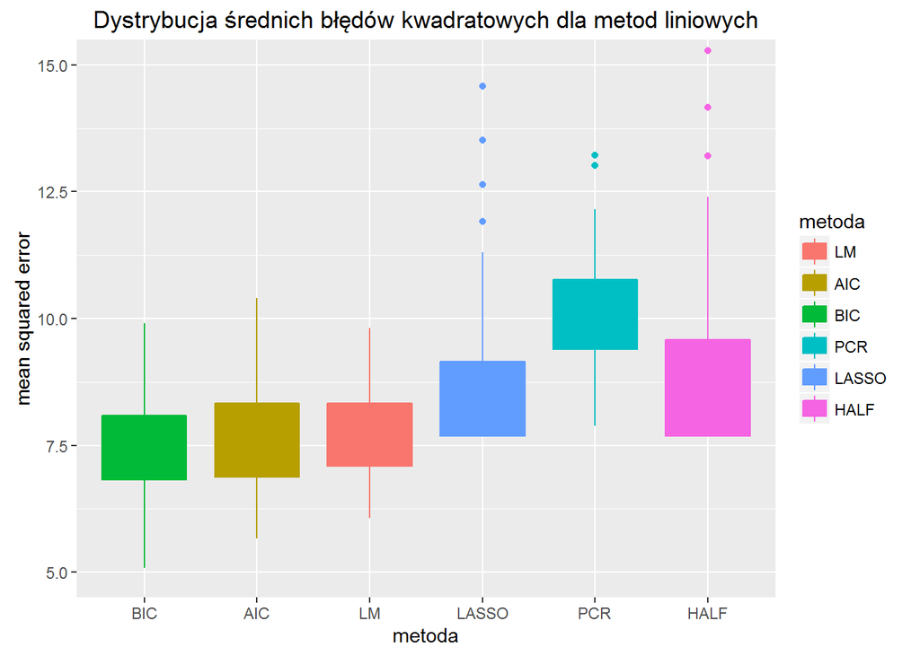

Najlepszą spośród metod liniowych okazała się ta minimalizująca kryterium BIC, przy czym metody AIC, BIC i LM wypadły bardzo podobnie. Modele z regularyzacją i PCR mają istotnie gorszą jakość.

# 4 Modele nieliniowe

## 4.1 algorytm k-najbliższych sąsiadów

Pierwszy wypróbowany model bazował na algorytmie najbliżzych sąsiadów. Aby wyznaczyć optymalną liczbę najbliższych obserwacji k, obliczono błąd średniokwadratowy dla k = 1, …, 25.

```
## [1] 11
```

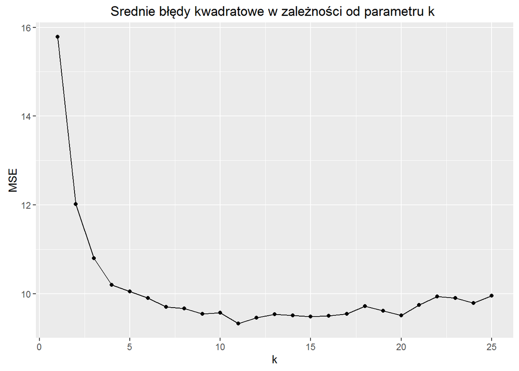

## 4.2 Drzewa decyzyjne

Kolejnym wypróbowanym modelem było drzewo decyzyjne.

```
##
## Regression tree:
## tree(formula = dane2$chore ~ ., data = dane2)
## Variables actually used in tree construction:
## [1] "new_2"     "new_1"     "age"       "urbaniz_1"
## Number of terminal nodes:  6
## Residual mean deviance:  8.047 = 36550 / 4542
## Distribution of residuals:
##     Min.  1st Qu.   Median     Mean  3rd Qu.     Max.
## -13.8600  -0.4522  -0.4522   0.0000   0.7393  21.8700
```

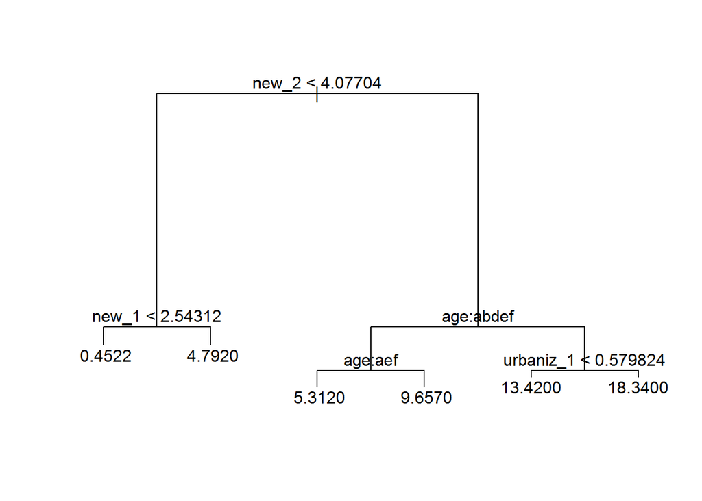

Zmienne użyte w konstrukcji drzewa to liczba nowych przypadków w dwóch kolejnych latach, grupa wiekowa i współczynnik urbanizacji. Co zaskakujące, nie została wzięta pod uwagę płeć.

## 4.3 Lasy losowe

Dla algorytmu lasów losowych wyznaczono ważność zmiennych użytych w modelu.

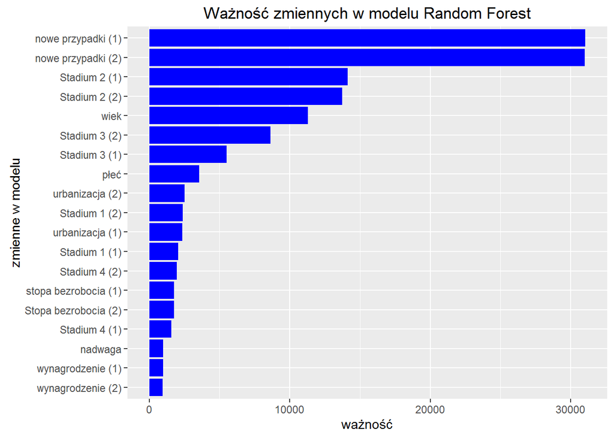

Sprawdzono też, jak wyglądałaby ważność zmiennych, gdyby z modelu wyłączyć różne stadia choroby.

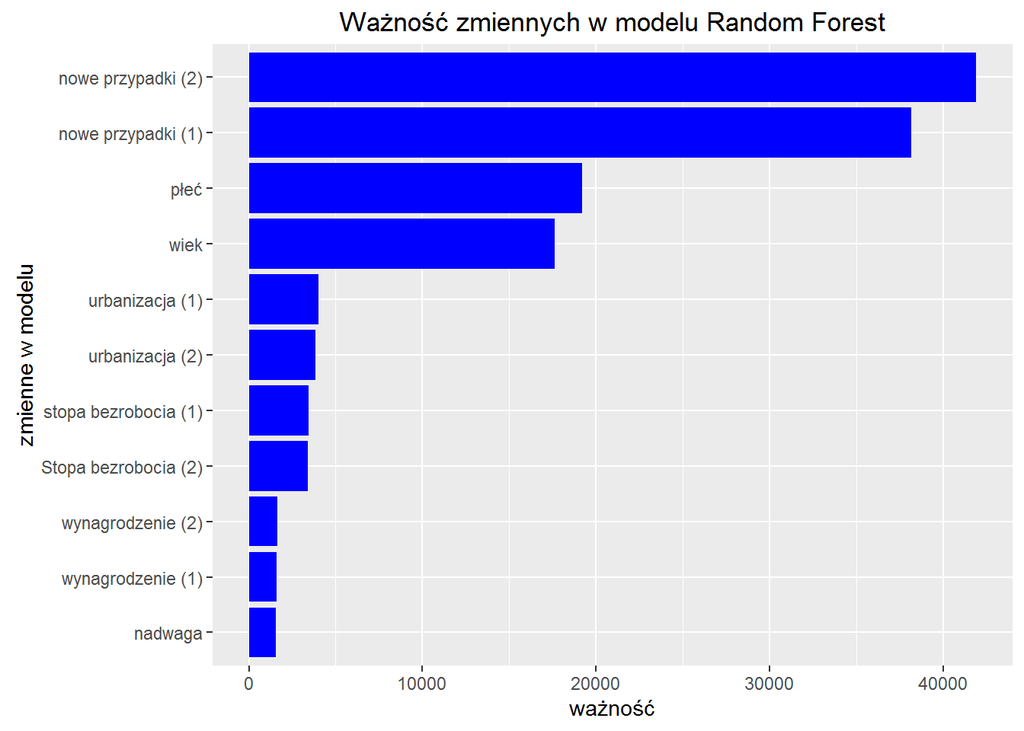

Najważniejszymi zmiennymi są liczby nowych przypadków w dwóch kolejnych latach. Dość istotne są dane ze stadiów 2 i 3, mniej ze stadiów 1 i 4. Wiek i płeć odgrywają kluczową rolę. Z dodatkowych czynników włączonych do modelu najważniejszy okazał się wskaźnik urbanizacji. Mniejszą rolę odgrywa stopa bezrobocia, zaś nadwaga i wynagrodzenie nie okazały się istotne.

## 4.4 Gradient boosting

Aby zbudować model przy pomocy funkcji xgboost, zmienne jekościowe takie jak płeć i wiek zostały przekształcone w dummy variables.

Na podstawie stworzonego modelu została wyznaczona ważność zmiennych.

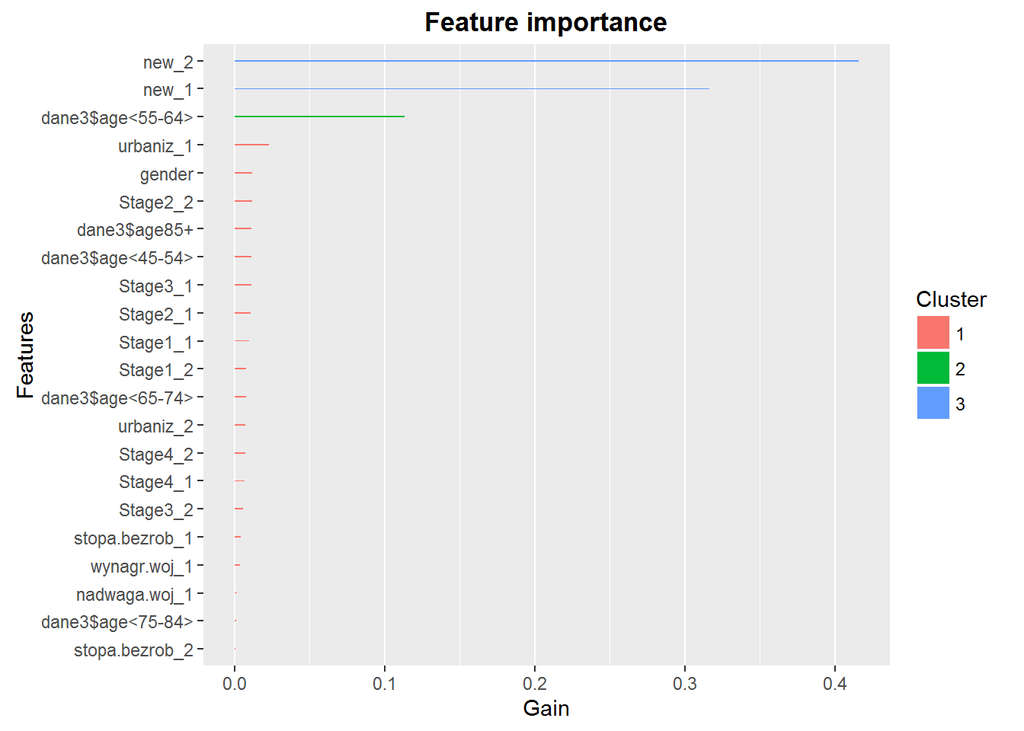

Wnioski są podobne, jak w przypadku analogicznego wykresu w metodzie random forest. Najważniejsze okazują się liczby nowych przypadków, istotna jest urbanizacja, zaś mierniki jakości życia są znacznie mniej ważne. Istotna jest grupa wiekowa 55 - 64 lata.

# 5 Porównanie użytych metod

Aby ocenić użyte metody nieliniowe, przedstawiono dystrybucje błędów średniokwadratowych

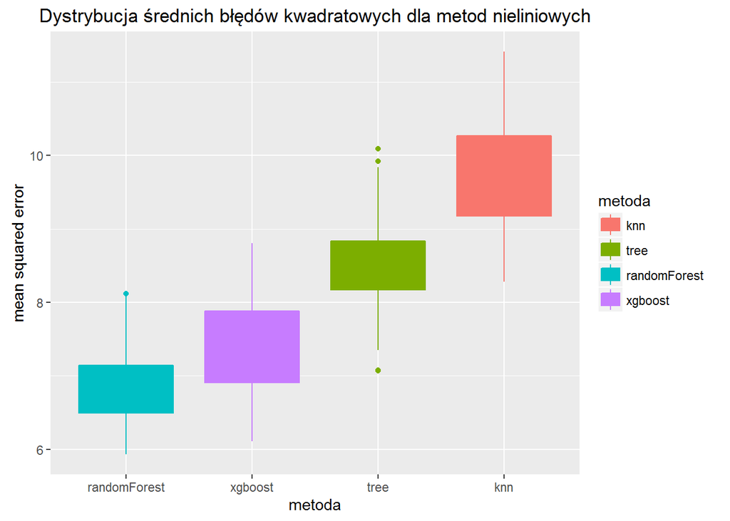

Najniższym błędem charakteryzuje się metoda lasów losowych. Rozkład MSE dla tej metody ma też najniższe odchylenie standardowe.

Sprawdzono, jak wypadają metody nieliniowe w porównaniu do liniowych. Na wykresie pominięto niektóre metody o wyższym MSE.

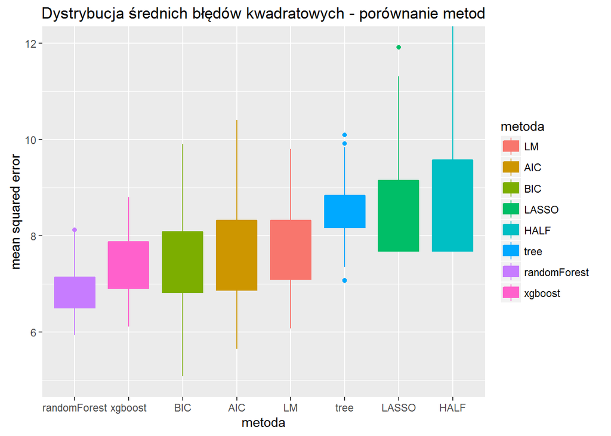

Ze wszystkich sprawdzonych metod najlepsza to lasy losowe. Trochę gorzej i podobnie do siebie wypadają: boosting, LM, AIC oraz BIC.

# 6 Predykcja na rok 2013 - prezentacja wyników

Jako, że MSE okazał się najmniejszy dla metody lasów losowych, wyniki przedykcji z użyciem tej metody wykorzystano do wygenerowania poniższych wykresów.

Na kartogramach przedstawiono zachorowania w powiatach dla kobiet i mężczyzn zagregowane po grupach wekowych.

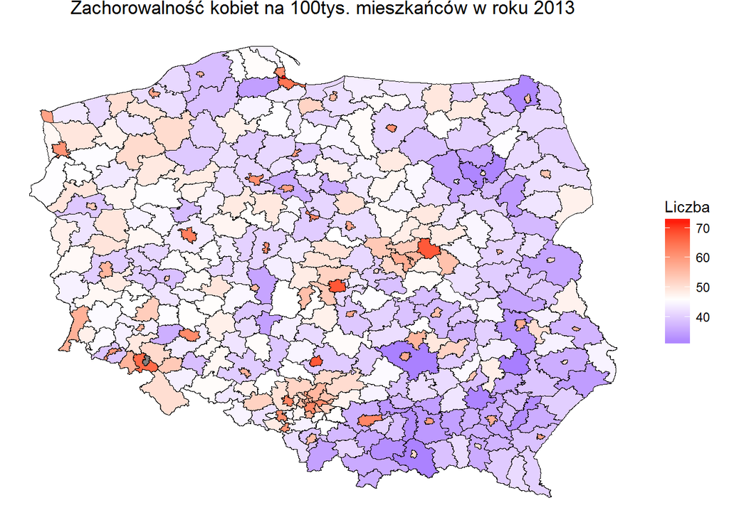

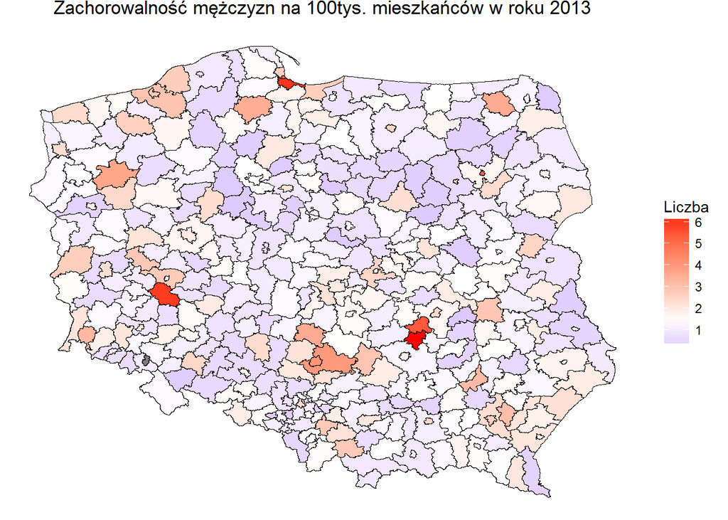

Należy mieć świadomość, że predykcja dla mężczyzn jest obarczona dużym błędem ze względu na niewielką liczbę przypadków choroby.

# 7 Podsumowanie

W raporcie przedstawione zostały modele predykcyjne dla zachorowań na nowotwory piersi w roku 2013. Metodą o najmniejszym błędzie średniokwadratowym okazały się lasy losowe. Dokładniejsza analiza modeli pozwala wyciągnąć wniosek, że istotnymi czynnikami w analizie predykcyjnej są płeć, wiek, liczba nowych przypadków i przypadków w różnych stadiach choroby oraz wskaźnik urbanizacji. Inne zmienne uwzględnione w modelu mają mniejsze znaczenie. Pozwala to podejrzewać, że model można jeszcze udoskonalić, szukając innych zmiennych mających wpływ na liczbę zachorowań.